# R Notebook

Preliminary set up.

Install these packages.

```r
## Packages you may need - need to load every session if you are in the cloud
## Trying something new that should play better with R
if (!require("pacman")) install.packages("pacman") #pacman is the package that installs packages nicely
pacman::p_load(gapminder, fixest, tidyverse, ggplot2, dplyr, stargazer, modelsummary) #these are the packages you may need
```

Load your libraries.

```r
## The cloud server has tidyverse and ggplot2, but be sure to install those on your home machine if you are using that.
library(gapminder)
library(fixest)
library(ggplot2)
library(tidyverse)
library(stargazer)
library(modelsummary)
```

Now get data. We are using gapminder data and a pre-loaded dataset called “swiss.” It contains province-level statistics on fertility and socio-economics in 1888 for the 47 French-speaking provinces in Switzerland. This is mid-demographic transition in this country.

```r
## It isn't strictly necessary to load these into data frames, but this is good practice for working with external data and it will allow you to make nice tables with stargazer
DF_gap<-as.data.frame(gapminder)
stargazer(DF_gap[c("lifeExp","gdpPercap")], type = "text")
```

```
=======================================================
Statistic   N     Mean    St. Dev.    Min       Max
-------------------------------------------------------
lifeExp   1,704  59.474    12.917   23.599    82.603
gdpPercap 1,704 7,215.327 9,857.455 241.166 113,523.100
-------------------------------------------------------
```

## Linear Regression and Dummy Variables Using Gapminder

First, let’s plot the gap minder data again:

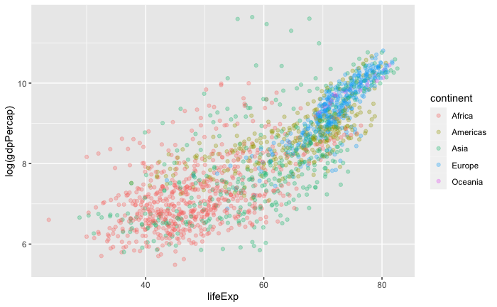

```r
## First for all years and continents
ggplot(data=DF_gap, aes(lifeExp,log(gdpPercap), color=continent))+geom_point(alpha = 0.3,  position = position_jitter())
```

We can estimate the slope and intercept of this line

```r
model1<-lm(lifeExp ~ log(gdpPercap), DF_gap)
modelsummary(model1, color = "black") ##Stargazer is nice, but it won't work for the fixed effects (feols) models below.
```

|  | Model 1 |
| --- | --- |
| (Intercept) | −9.101 |
|  | (1.228) |
| log(gdpPercap) | 8.405 |
|  | (0.149) |
| Num.Obs. | 1704 |
| R2 | 0.652 |
| R2 Adj. | 0.652 |
| AIC | 11760.4 |
| BIC | 11776.7 |
| Log.Lik. | −5877.210 |
| F | 3192.273 |
| RMSE | 7.62 |

```r
#stargazer(model1, type = "text")
```

But as you recognized in the first week exercise, this relationship is hiding some interesting heterogeneity. For example, look at the relationship between life expectancy and year:

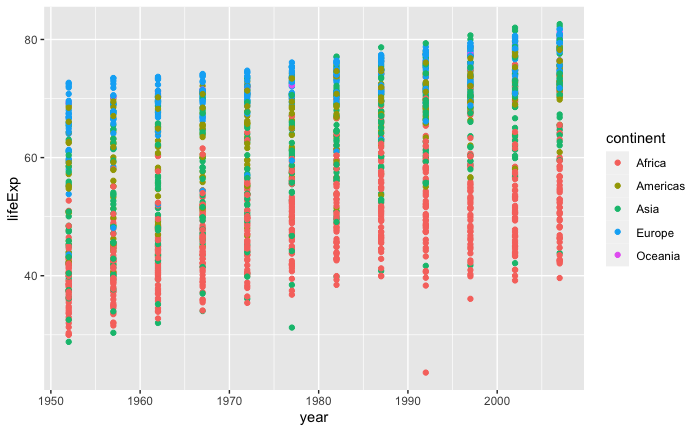

```r
ggplot(data=DF_gap, aes(year, lifeExp, color=continent))+geom_point()
```

Now lets look at the original relationship for one year.

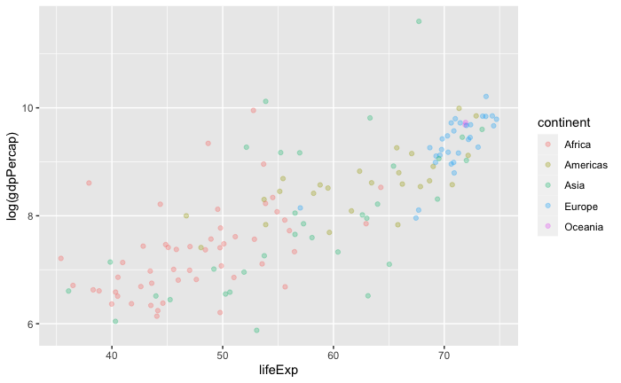

```r
## Then just for one year (can change year or even continent here)
gapminder %>%
  filter(year==1972) %>%
  ggplot(aes(lifeExp,log(gdpPercap), color=continent))+geom_point(alpha = 0.3,  position = position_jitter())
```

What we see in this data is that there are probably underlying patterns by year and continent that we aren’t fully accounting for in a simple regression.

```r
model2 <-feols(lifeExp ~ log(gdpPercap) + factor(continent) + factor(year), data=DF_gap)
modelsummary(model2)
```

|  | Model 1 |
| --- | --- |
| (Intercept) | 5.143 |
|  | (1.183) |
| log(gdpPercap) | 4.996 |
|  | (0.159) |
| factor(continent)Americas | 8.964 |
|  | (0.461) |
| factor(continent)Asia | 7.086 |
|  | (0.394) |
| factor(continent)Europe | 12.566 |
|  | (0.508) |
| factor(continent)Oceania | 12.821 |
|  | (1.269) |
| factor(year)1957 | 1.747 |
|  | (0.687) |
| factor(year)1962 | 3.230 |
|  | (0.688) |
| factor(year)1967 | 4.556 |
|  | (0.690) |
| factor(year)1972 | 5.721 |
|  | (0.693) |
| factor(year)1977 | 7.131 |
|  | (0.695) |
| factor(year)1982 | 8.872 |
|  | (0.696) |
| factor(year)1987 | 10.480 |
|  | (0.697) |
| factor(year)1992 | 11.462 |
|  | (0.696) |
| factor(year)1997 | 11.920 |
|  | (0.699) |
| factor(year)2002 | 12.244 |
|  | (0.701) |
| factor(year)2007 | 12.760 |
|  | (0.706) |
| Num.Obs. | 1704 |
| R2 | 0.801 |
| R2 Adj. | 0.799 |
| RMSE | 5.76 |
| Std.Errors | IID |

```r
# Regression with same slope but different intercepts for each continent
DF_gap_67<-filter(DF_gap, year==1967)
fm <- feols(lifeExp ~ i(continent)+gdpPercap*i(continent), data=DF_gap_67)
```

```
The variable 'gdpPercap:continent::Oceania' has been removed because of collinearity (see $collin.var).
```

```r
modelsummary(fm)
```

|  | Model 1 |
| --- | --- |
| (Intercept) | 44.244 |
|  | (1.122) |
| continent = Americas | 9.631 |
|  | (2.508) |
| continent = Asia | 9.238 |
|  | (1.673) |
| continent = Europe | 19.673 |
|  | (3.082) |
| continent = Oceania | 124.934 |
|  | (2157.292) |
| gdpPercap | −0.007 |
|  | (0.149) |
| gdpPercap × continent = Africa | 0.007 |
|  | (0.149) |
| gdpPercap × continent = Americas | 0.008 |
|  | (0.149) |
| gdpPercap × continent = Asia | 0.007 |
|  | (0.149) |
| gdpPercap × continent = Europe | 0.007 |
|  | (0.149) |
| Num.Obs. | 142 |
| R2 | 0.708 |
| R2 Adj. | 0.688 |
| RMSE | 6.31 |
| Std.Errors | IID |

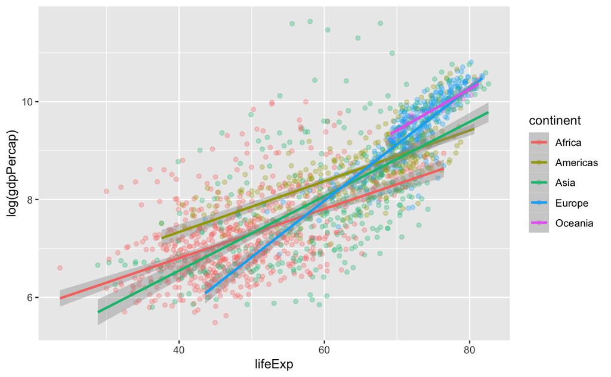

```r
## We can plot this!
ggplot(data=DF_gap, aes(lifeExp,log(gdpPercap), color=continent))+geom_point(alpha = 0.3,  position = position_jitter())+stat_smooth(method="lm")
```

## Regression with Control Variables Using “swiss” Data

Now let’s look at data with a few more control variables. The fertility/agriculture/catholic variables are from 0-100.

```r
data(swiss)
DF_swiss<-as.data.frame(swiss)
stargazer(DF_swiss, type = "text")
```

```
==================================================
Statistic        N   Mean  St. Dev.  Min     Max
--------------------------------------------------
Fertility        47 70.143  12.492  35.000 92.500
Agriculture      47 50.660  22.711  1.200  89.700
Examination      47 16.489  7.978     3      37
Education        47 10.979  9.615     1      53
Catholic         47 41.144  41.705  2.150  100.000
Infant.Mortality 47 19.943  2.913   10.800 26.600
--------------------------------------------------
```

How should we look at this data on a graph?

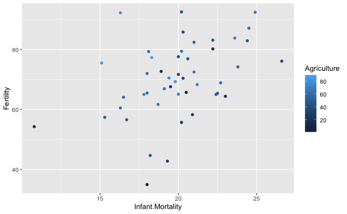

```r
## Let's try to plot Fertility vs. Infant Mortalit while looking at variation in different variables.
ggplot(data=DF_swiss, aes(Infant.Mortality, Fertility, color=Agriculture)) + geom_point()
```

Now let’s look at these relationships a little more carefully with linear regression.

```r
model3 <- feols(Fertility ~ Infant.Mortality, data=DF_swiss)
summary(model3)
```

```
OLS estimation, Dep. Var.: Fertility
Observations: 47
Standard-errors: IID
```

|  | Estimate | Std. Error | t value | Pr(>\|t\|) |  |
| --- | --- | --- | --- | --- | --- |
| (Intercept) | 34.51546 | 11.711272 | 2.94720 | 0.0050664 | ** |
| Infant.Mortality | 1.78649 | 0.581214 | 3.07371 | 0.0035852 | ** |

```
---
Signif. codes:  0 '***' 0.001 '**' 0.01 '*' 0.05 '.' 0.1 ' ' 1
RMSE: 11.2   Adj. R2: 0.155153
```

How do we interpret this relationship? Does it change if we add control variables? How do you interpret the coefficients on the variables? Be sure to take statistical signicance into account in your interpretation.

```r
model4 <- feols(Fertility ~ Infant.Mortality + Catholic + Agriculture + Education + Examination, data=DF_swiss)
summary(model4)
```

```
OLS estimation, Dep. Var.: Fertility
Observations: 47
Standard-errors: IID
```

|  | Estimate | Std. Error | t value | Pr(>\|t\|) |  |
| --- | --- | --- | --- | --- | --- |
| (Intercept) | 66.915182 | 10.706038 | 6.25023 | 1.9061e-07 | *** |
| Infant.Mortality | 1.077048 | 0.381720 | 2.82157 | 7.3357e-03 | ** |
| Catholic | 0.104115 | 0.035258 | 2.95297 | 5.1901e-03 | ** |
| Agriculture | -0.172114 | 0.070304 | -2.44814 | 1.8727e-02 | * |
| Education | -0.870940 | 0.183029 | -4.75849 | 2.4306e-05 | *** |
| Examination | -0.258008 | 0.253878 | -1.01627 | 3.1546e-01 |  |

```
---
Signif. codes:  0 '***' 0.001 '**' 0.01 '*' 0.05 '.' 0.1 ' ' 1
RMSE: 6.69239   Adj. R2: 0.670971
```

```r
#stargazer(model4, type = "text")
```

Does the relationship between these variables look like what we would expect based on what we have learned and seen so far? Why do think the differences exist?